# Data Visualization

We covered some basic notions regarding with the plotting in the [pandas](https://itueconomics.github.io/bil113e/python3-pandas.html) course. We will cover [matplotlib.pyplot](https://matplotlib.org/api/pyplot_api.html) for data visualization in Python.

- Download the Data Visualization Notebook

Let's start with importing necessary libraries:

```python
import numpy as np
import pandas as pd
import matplotlib.pyplot as plt
```

```python
x = np.arange(0, 5, 0.1);
y = np.sin(x)
plt.plot(x, y)
```

It looks like nothing appeared but a text. You should command it to plot:

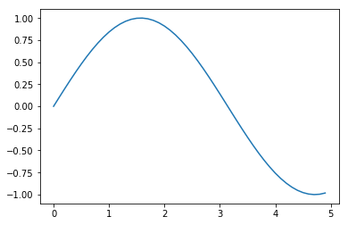

```python
plt.show()
```

If you don't want to bother with writing this each time for plotting you can use this command:

```python
%matplotlib inline
```

From now on plots will be shown without `plt.show()` command.

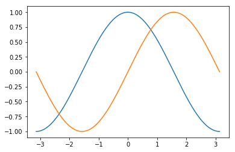

```python
X = np.linspace(-np.pi, np.pi, 256, endpoint=True) # generating 256 linear points between -pi and +pi
C, S = np.cos(X), np.sin(X)
plt.plot(X, C)
plt.plot(X, S)
```

We actually combined two plots of the `sin()` and `cos()` functions.

This plotting is done with the default settings. You can manipulate the features of the plot. Check for the [matplotlib.pyplot](https://matplotlib.org/api/pyplot_api.html) documentation.

For example you can change the size of the plot:

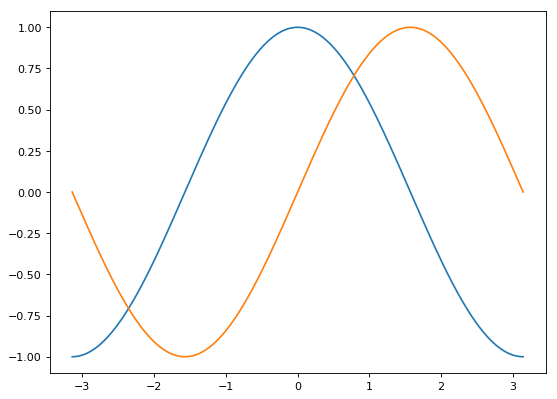

```python
plt.figure(figsize=(8,6), dpi=80)
plt.plot(X, C)
plt.plot(X, S)
```

You can change the colors:

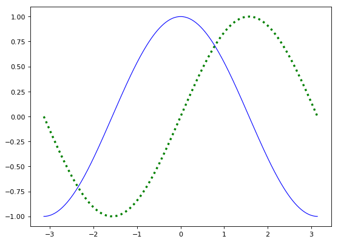

```python
plt.figure(figsize=(8,6), dpi=80)
plt.plot(X, C, color="blue", linewidth=1.0, linestyle="-")
plt.plot(X, S, color="green", linewidth=3.0, linestyle=":")
```

```
 <a list of 20 Text yticklabel objects>)
```

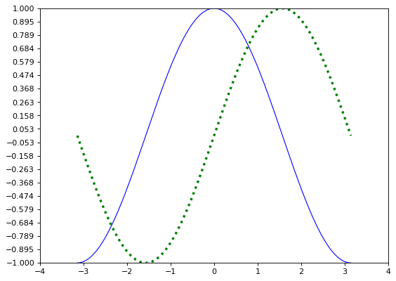

```python
plt.figure(figsize=(8,6), dpi=80)
plt.plot(X, C, color="blue", linewidth=1.0, linestyle="-")
plt.plot(X, S, color="green", linewidth=3.0, linestyle=":")
plt.xlim(-4.0,4.0)
# Set x ticks
plt.xticks(np.linspace(-4,4,9,endpoint=True))
# Set y limits
plt.ylim(-1.0,1.0)
# Set y ticks
plt.yticks(np.linspace(-1,1,20,endpoint=True))
```

Let's add some grid:

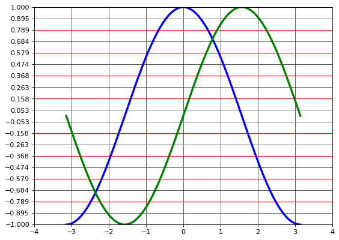

```python
plt.figure(figsize=(8,6), dpi=80)
plt.plot(X, C, color="blue", linewidth=3.0, linestyle="-")
plt.plot(X, S, color="green", linewidth=3.0, linestyle="-")
plt.xlim(-4.0,4.0)
# Set x ticks
plt.xticks(np.linspace(-4,4,9,endpoint=True))
# Set y limits
plt.ylim(-1.0,1.0)
# Set y ticks
plt.yticks(np.linspace(-1,1,20,endpoint=True))
plt.grid(color='red')
```

We can label the ticks:

```
 <a list of 3 Text yticklabel objects>)
```

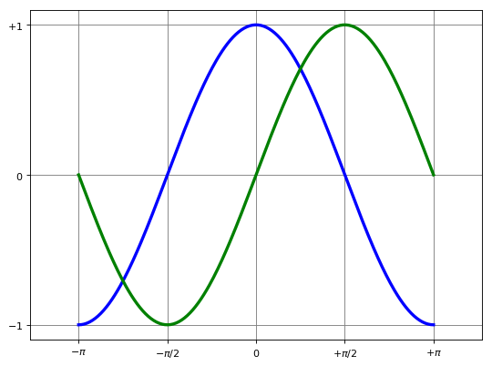

```python
plt.figure(figsize=(8,6), dpi=80)
plt.plot(X, C, color="blue", linewidth=3.0, linestyle="-")
plt.plot(X, S, color="green", linewidth=3.0, linestyle="-")
plt.xlim(-4.0,4.0)
# Set x ticks
# Set y limits
# Set y ticks
plt.grid(color='grey')
plt.xticks([-np.pi, -np.pi/2, 0, np.pi/2, np.pi],
       [r'$-\pi$', r'$-\pi/2$', r'$0$', r'$+\pi/2$', r'$+\pi$'])

plt.yticks([-1, 0, +1],
       [r'$-1$', r'$0$', r'$+1$'])
```

Withing the `$` signs you can use `latex/markdown` formatting.

It look's like we can save the it as figure:

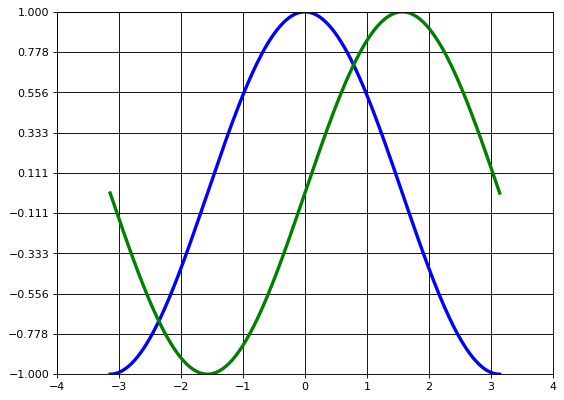

```python
plt.figure(figsize=(8,6), dpi=80)
plt.plot(X, C, color="blue", linewidth=3.0, linestyle="-")
plt.plot(X, S, color="green", linewidth=3.0, linestyle="-")
plt.xlim(-4.0,4.0)
# Set x ticks
plt.xticks(np.linspace(-4,4,9,endpoint=True))
# Set y limits
plt.ylim(-1.0,1.0)
# Set y ticks
plt.yticks(np.linspace(-1,1,10,endpoint=True))
plt.grid(color='black')
plt.savefig('fig.png')
```

Add a legend:

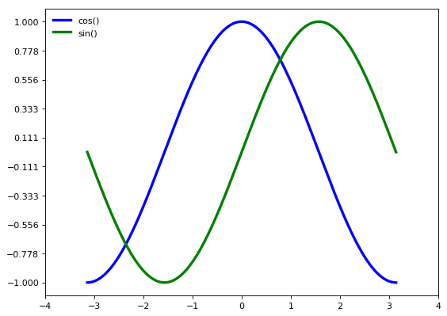

```python
plt.figure(figsize=(8,6), dpi=80)
plt.plot(X, C, color="blue", linewidth=3.0, linestyle="-", label = 'cos()')
plt.plot(X, S, color="green", linewidth=3.0, linestyle="-", label='sin()')
plt.xlim(-4.0,4.0)
plt.xticks(np.linspace(-4,4,9,endpoint=True))
plt.yticks(np.linspace(-1,1,10,endpoint=True))
plt.legend(loc='upper left', frameon=False)
```

Annotate some points:

```
Text(10,-30,'sin(0) = 0')
```

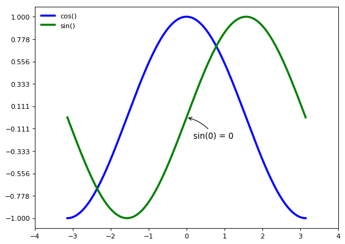

```python
plt.figure(figsize=(8,6), dpi=80)
plt.plot(X, C, color="blue", linewidth=3.0, linestyle="-", label = 'cos()')
plt.plot(X, S, color="green", linewidth=3.0, linestyle="-", label='sin()')
plt.xlim(-4.0,4.0)
plt.xticks(np.linspace(-4,4,9,endpoint=True))
plt.yticks(np.linspace(-1,1,10,endpoint=True))
plt.legend(loc='upper left', frameon=False)
plt.annotate(s='sin(0) = 0', xy = (0,0),
            xytext=(+10, -30), textcoords='offset points', fontsize=12,
            arrowprops=dict(arrowstyle="->", connectionstyle="arc3,rad=.2"))
```

Explanation of the `annotate()` attributes:

- s: Text
- xy: a `tuple` that gives the coordinates of the points.
- xytext: coordinates of the text. In this case it means relative coordinates of the text respect to the point.
- textcoords: have two options (1) `points` - offset (in points) from the xy value; (2) `pixels` - offset (in pixels) from the xy value
- arrowprops: It gives attributes how to connect to the points.

For now you are not necessarily learn the details. It is enough to know what you can do while plotting a data.

## Movies Database

Do you remember the dataset we manipulated in the [pandas](https://itueconomics.github.io/bil113e/python3-pandas.html) course? We actually saved it as csv file names movies_new.csv. Okay download the dataset and import it.

```python
mv = pd.read_csv('movies_new.csv',encoding='latin1')
mv.head()
```

|  | Unnamed: 0 | movieId | title | year | Action | Adventure | Animation | Children | Comedy | Crime | ... | Film-Noir | Horror | IMAX | Musical | Mystery | Romance | Sci-Fi | Thriller | War | Western |
| --- | --- | --- | --- | --- | --- | --- | --- | --- | --- | --- | --- | --- | --- | --- | --- | --- | --- | --- | --- | --- | --- |
| 0 | 0 | 1 | Toy Story | 1995 | False | True | True | True | True | False | ... | False | False | False | False | False | False | False | False | False | False |
| 1 | 1 | 2 | Jumanji | 1995 | False | True | False | True | False | False | ... | False | False | False | False | False | False | False | False | False | False |
| 2 | 2 | 3 | Grumpier Old Men | 1995 | False | False | False | False | True | False | ... | False | False | False | False | False | True | False | False | False | False |
| 3 | 3 | 4 | Waiting to Exhale | 1995 | False | False | False | False | True | False | ... | False | False | False | False | False | True | False | False | False | False |
| 4 | 4 | 5 | Father of the Bride Part II | 1995 | False | False | False | False | True | False | ... | False | False | False | False | False | False | False | False | False | False |

5 rows × 23 columns

Let's find out the categories:

```python
cat_names = mv.columns
cat_names = cat_names[4:]
print(cat_names, '\n',len(cat_names))
```

```
Index(['Action', 'Adventure', 'Animation', 'Children', 'Comedy', 'Crime',
       'Documentary', 'Drama', 'Fantasy', 'Film-Noir', 'Horror', 'IMAX',
       'Musical', 'Mystery', 'Romance', 'Sci-Fi', 'Thriller', 'War',
       'Western'],
      dtype='object')
 19
```

We have 19 categories.

```python
cat = mv[cat_names].sum().sort_values()
cat
```

```
Film-Noir       133
IMAX            153
Western         168
War             367
Musical         393
Animation       446
Documentary     494
Mystery         542
Children        583
Fantasy         652
Sci-Fi          788
Horror          875
Crime          1099
Adventure      1115
Action         1543
Romance        1544
Thriller       1726
Comedy         3313
Drama          4359
dtype: int64
```

Let's make a histogram:

```
Text(0,0.5,'Counts')
```

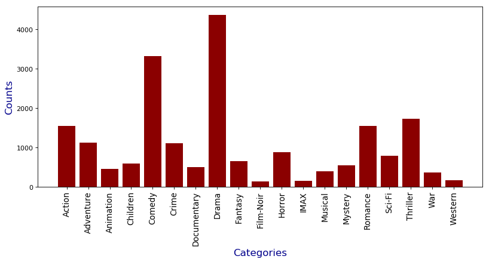

```python
plt.figure(figsize=(12,5), dpi=80)
plt.bar(cat.index, cat.values, color='darkred')
plt.xticks(rotation=90, fontsize=12)
plt.xlabel('Categories',fontsize=15,color='darkblue')
plt.ylabel('Counts',fontsize=15,color='darkblue')
```

May be a pie chart works better? Also see this [example](https://matplotlib.org/examples/pie_and_polar_charts/pie_demo_features.html)

```
 [Text(1.09977,0.0226473,'Film-Noir'),
  Text(1.09769,0.0713027,'IMAX'),
  Text(1.09279,0.125741,'Western'),
  Text(1.07864,0.215716,'War'),
  Text(1.04586,0.340842,'Musical'),
  Text(0.992906,0.473433,'Animation'),
  Text(0.913758,0.61241,'Documentary'),
  Text(0.80423,0.750476,'Mystery'),
  Text(0.662018,0.878483,'Children'),
  Text(0.483018,0.988278,'Fantasy'),
  Text(0.25257,1.07061,'Sci-Fi'),
  Text(-0.0283506,1.09963,'Horror'),
  Text(-0.357877,1.04016,'Crime'),
  Text(-0.686637,0.859377,'Adventure'),
  Text(-0.97305,0.513004,'Action'),
  Text(-1.09997,0.00800369,'Romance'),
  Text(-1.0537,-0.574213,'Thriller'),
  Text(-0.316384,-1.05352,'Comedy'),
  Text(0.858899,-0.687236,'Drama')])
```

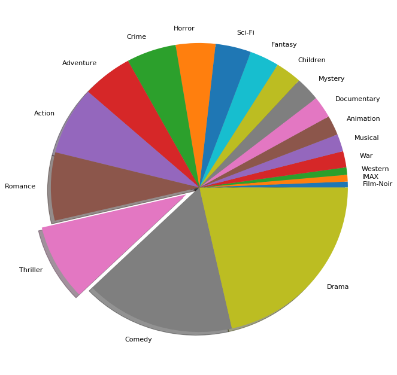

```python
plt.figure(figsize=(10,10), dpi=80)
exp= [0] * 16 + [0.1] + [0] * 2
plt.pie(cat, explode = exp, labels=cat.index,shadow=True)
```

For better visualization we can cut-off some categories:

```python
pop_cat = cat[-12:]
```

```
 [Text(1.09516,0.103108,'Mystery'),
  Text(1.05447,0.313195,'Children'),
  Text(0.963959,0.529889,'Fantasy'),
  Text(0.803345,0.751423,'Sci-Fi'),
  Text(0.556805,0.948666,'Horror'),
  Text(0.206524,1.08044,'Crime'),
  Text(-0.212695,1.07924,'Adventure'),
  Text(-0.670022,0.872394,'Action'),
  Text(-1.02104,0.409241,'Romance'),
  Text(-1.0812,-0.202499,'Thriller'),
  Text(-0.539794,-0.958448,'Comedy'),
  Text(0.80113,-0.753785,'Drama')])
```

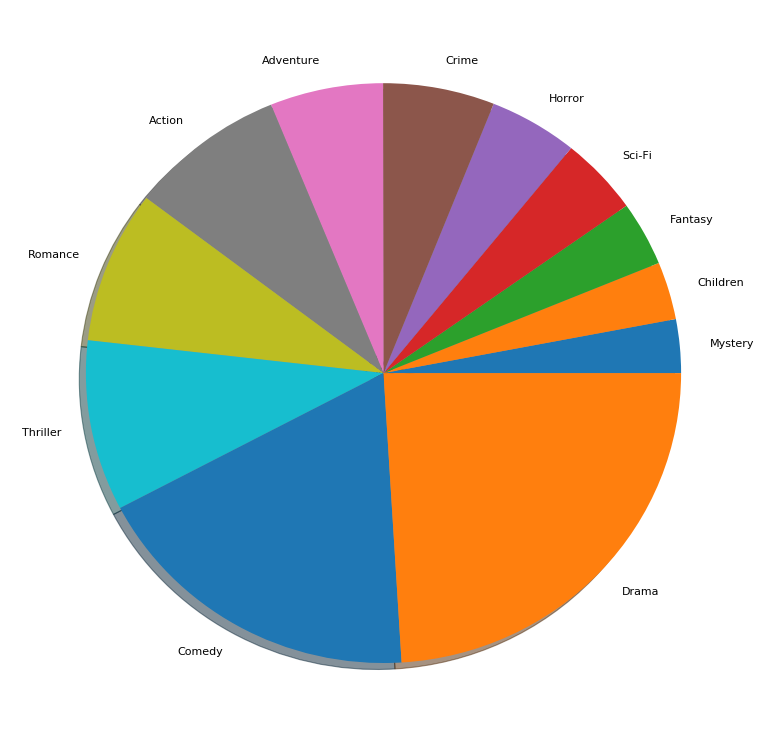

```python
plt.figure(figsize=(12,12), dpi=80)
plt.pie(pop_cat, labels=pop_cat.index,shadow=True)
```

Second thing we can do with our data is to count number of movies for each year.

```python
yrs = mv['year'].value_counts()
yrs.head()
```

```
2000    279
1996    274
2002    271
1998    270
2001    267
Name: year, dtype: int64
```

```python
yrs = yrs.sort_index()
```

```
Text(0,0.5,'Counts')
```

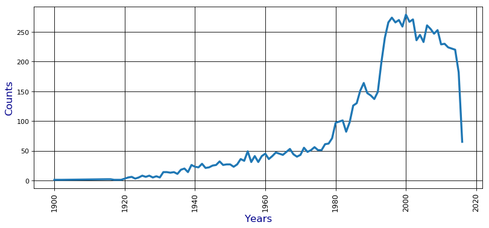

```python
plt.figure(figsize=(12,5), dpi=80)
plt.plot(yrs, linewidth=3.0, linestyle="-")
plt.xticks(rotation=90, fontsize=11)
plt.grid(color='black')
plt.xlabel('Years',fontsize=15,color='darkblue')
plt.ylabel('Counts',fontsize=15,color='darkblue')
```

## Some Examples

When you examine the examples below you will notice that how advanced plotting can be done with matplotlib. These examples are taken from: https://www.labri.fr/perso/nrougier/teaching/matplotlib/

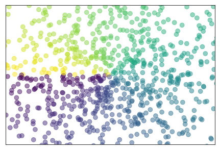

```python
n = 1024
X = np.random.normal(0,1,n)
Y = np.random.normal(0,1,n)
T = np.arctan2(Y,X)

plt.axes([0.025,0.025,0.95,0.95])
plt.scatter(X,Y, s=75, c=T, alpha=.5)

plt.xlim(-1.5,1.5), plt.xticks([])
plt.ylim(-1.5,1.5), plt.yticks([])
# savefig('../figures/scatter_ex.png',dpi=48)
plt.show()
```

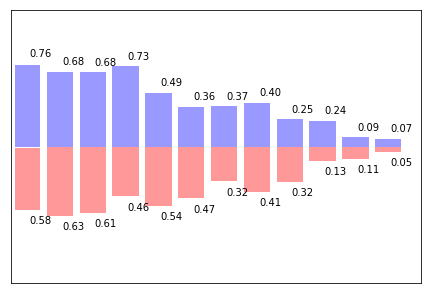

```python
n = 12
X = np.arange(n)
Y1 = (1-X/float(n)) * np.random.uniform(0.5,1.0,n)
Y2 = (1-X/float(n)) * np.random.uniform(0.5,1.0,n)

plt.axes([0.025,0.025,0.95,0.95])
plt.bar(X, +Y1, facecolor='#9999ff', edgecolor='white')
plt.bar(X, -Y2, facecolor='#ff9999', edgecolor='white')

for x,y in zip(X,Y1):
    plt.text(x+0.4, y+0.05, '%.2f' % y, ha='center', va= 'bottom')

for x,y in zip(X,Y2):
    plt.text(x+0.4, -y-0.05, '%.2f' % y, ha='center', va= 'top')

plt.xlim(-.5,n), plt.xticks([])
plt.ylim(-1.25,+1.25), plt.yticks([])

# savefig('../figures/bar_ex.png', dpi=48)
plt.show()
```

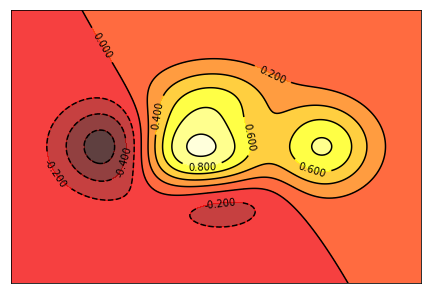

```python
def f(x,y):
    return (1-x/2+x**5+y**3)*np.exp(-x**2-y**2)

n = 256
x = np.linspace(-3,3,n)
y = np.linspace(-3,3,n)
X,Y = np.meshgrid(x,y)

plt.axes([0.025,0.025,0.95,0.95])

plt.contourf(X, Y, f(X,Y), 8, alpha=.75, cmap=plt.cm.hot)
C = plt.contour(X, Y, f(X,Y), 8, colors='black', linewidth=.5)
plt.clabel(C, inline=1, fontsize=10)

plt.xticks([]), plt.yticks([])
plt.show()
```

```
(([], <a list of 0 Text xticklabel objects>),
 ([], <a list of 0 Text yticklabel objects>))
```

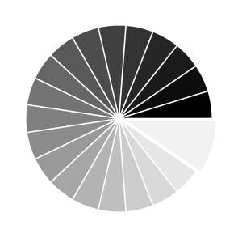

```python
n = 20
Z = np.ones(n)
Z[-1] *= 2

plt.axes([0.025,0.025,0.95,0.95])

plt.pie(Z, explode=Z*.05, colors = ['%f' % (i/float(n)) for i in range(n)])
plt.gca().set_aspect('equal')
plt.xticks([]), plt.yticks([])
```

```
((-1, 8), ([], <a list of 0 Text yticklabel objects>))
```

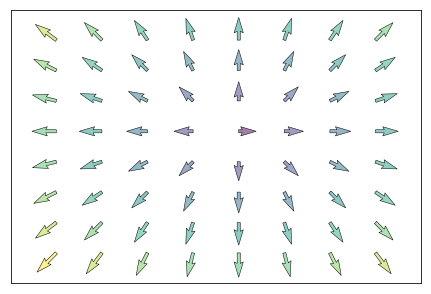

```python
n = 8
X,Y = np.mgrid[0:n,0:n]
T = np.arctan2(Y-n/2.0, X-n/2.0)
R = 10+np.sqrt((Y-n/2.0)**2+(X-n/2.0)**2)
U,V = R*np.cos(T), R*np.sin(T)

plt.axes([0.025,0.025,0.95,0.95])
plt.quiver(X,Y,U,V,R, alpha=.5)
plt.quiver(X,Y,U,V, edgecolor='k', facecolor='None', linewidth=.5)

plt.xlim(-1,n), plt.xticks([])
plt.ylim(-1,n), plt.yticks([])
```

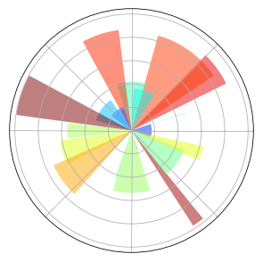

```python
ax = plt.axes([0.025,0.025,0.95,0.95], polar=True)

N = 20
theta = np.arange(0.0, 2*np.pi, 2*np.pi/N)
radii = 10*np.random.rand(N)
width = np.pi/4*np.random.rand(N)
bars = plt.bar(theta, radii, width=width, bottom=0.0)

for r,bar in zip(radii, bars):
    bar.set_facecolor( plt.cm.jet(r/10.))
    bar.set_alpha(0.5)

ax.set_xticklabels([])
ax.set_yticklabels([])
# savefig('../figures/polar_ex.png',dpi=48)
plt.show()
```

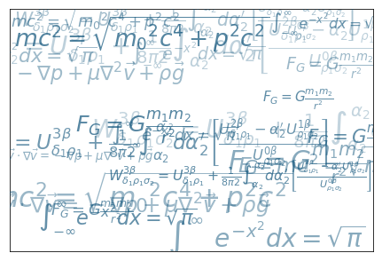

```python
eqs = []
eqs.append((r"$W^{3\beta}_{\delta_1 \rho_1 \sigma_2} = U^{3\beta}_{\delta_1 \rho_1} + \frac{1}{8 \pi 2} \int^{\alpha_2}_{\alpha_2} d \alpha^\prime_2 \left[\frac{ U^{2\beta}_{\delta_1 \rho_1} - \alpha^\prime_2U^{1\beta}_{\rho_1 \sigma_2} }{U^{0\beta}_{\rho_1 \sigma_2}}\right]$"))
eqs.append((r"$\frac{d\rho}{d t} + \rho \vec{v}\cdot\nabla\vec{v} = -\nabla p + \mu\nabla^2 \vec{v} + \rho \vec{g}$"))
eqs.append((r"$\int_{-\infty}^\infty e^{-x^2}dx=\sqrt{\pi}$"))
eqs.append((r"$E = mc^2 = \sqrt{{m_0}^2c^4 + p^2c^2}$"))
eqs.append((r"$F_G = G\frac{m_1m_2}{r^2}$"))


plt.axes([0.025,0.025,0.95,0.95])

for i in range(24):
    index = np.random.randint(0,len(eqs))
    eq = eqs[index]
    size = np.random.uniform(12,32)
    x,y = np.random.uniform(0,1,2)
    alpha = np.random.uniform(0.25,.75)
    plt.text(x, y, eq, ha='center', va='center', color="#11557c", alpha=alpha,
             transform=plt.gca().transAxes, fontsize=size, clip_on=True)

plt.xticks([]), plt.yticks([])
# savefig('../figures/text_ex.png',dpi=48)
plt.show()
```

Matplotlib is very fundemental plotting library. Many of the plotting libraries are built on Matplotlib. You can check out for other libraries. Let's check out another library.

```python
import seaborn as sns
```

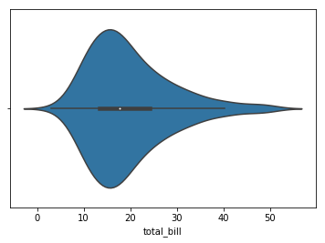

```python
tips = sns.load_dataset("tips")
sns.violinplot(x = "total_bill", data=tips)
```

`seaborn` is based on matplotlib so we can use matplotlib features with seaborn. For instance:

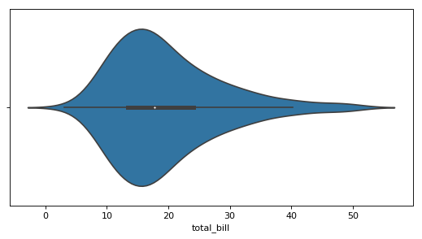

```python
plt.figure(figsize=(8,4), dpi=80)
tips = sns.load_dataset("tips")
sns.violinplot(x = "total_bill", data=tips)
```

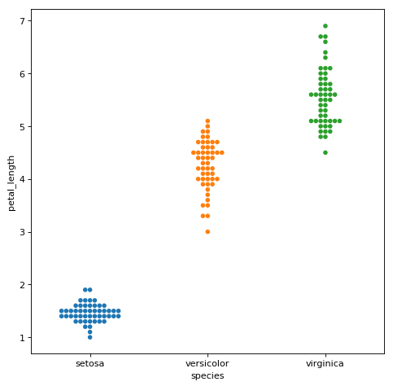

```python
plt.figure(figsize=(7,7), dpi=80)
# Load iris data
iris = sns.load_dataset("iris")
# Construct iris plot
sns.swarmplot(x="species", y="petal_length", data=iris)
```

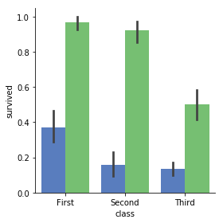

```python
titanic = sns.load_dataset("titanic")

# Set up a factorplot
g = sns.factorplot("class", "survived", "sex", data=titanic, kind="bar", palette="muted", legend=False)
```

seaborn default styles: `white, dark, whitegrid, darkgrid, ticks`.

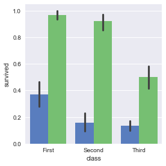

```python
sns.set() #default seaborn style
titanic = sns.load_dataset("titanic")
g = sns.factorplot("class", "survived", "sex", data=titanic, kind="bar", palette="muted", legend=False)
```

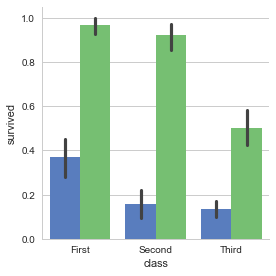

```python
sns.set_style('whitegrid') #default seaborn style
titanic = sns.load_dataset("titanic")
g = sns.factorplot("class", "survived", "sex", data=titanic, kind="bar", palette="muted", legend=False)
```

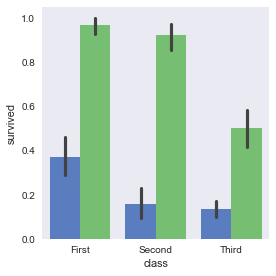

```python
sns.set_style('dark') #default seaborn style
titanic = sns.load_dataset("titanic")
g = sns.factorplot("class", "survived", "sex", data=titanic, kind="bar", palette="muted", legend=False)
```

Check out for [DataCamp SeaBorn Tutorial](https://www.datacamp.com/community/tutorials/seaborn-python-tutorial)

Objective of this course is to introduce basic plotting library of python. One importing thing should be pointed out that you do not need to grasp every detail of this features. This course should give you the intuition of how to plot data. You must get habit of learning what you need using documentations, or using Google :).

Check out for other data visualization libraries: [10 Useful Python Data Visualization Libraries for Any Discipline](https://blog.modeanalytics.com/python-data-visualization-libraries/)

# References

- https://www.labri.fr/perso/nrougier/teaching/matplotlib/
- https://seaborn.pydata.org/tutorial.html
- https://matplotlib.org/users/pyplot_tutorial.html
- https://matplotlib.org/api/pyplot_api.html